# Show Me The Money: NBA Contracts

Taban Yolo

11/20/2018

##NBA Project

The data set we are going to explore in this Project is NBA Players Salary as our response variable (y) given a players individual stats as the predictor values.

Given this, the question we would like to answer is: Are a player individual stats predictive of their Salary?

We will start by loading the data set into R and then fit the multiple linear regression model to fit the data.

```r
nbatable <- read.csv(file = "~/Desktop/Back up/Desktop/PSU Grad School/STAT 564/NBA Project/NBA-Project/NEW NBA.csv", header = TRUE)
nbatable
```

| NAME | POS | GP | SAL | MIN | PTS | FG | X3P | FT | AST | BLK | STL | REB | TOV | SALARY |
| --- | --- | --- | --- | --- | --- | --- | --- | --- | --- | --- | --- | --- | --- | --- |
| Stephen Curry | PG | 51 | $34,682,550\xe6(1) | 31.98 | 26.39 | 49.54 | 42.32 | 92.05 | 6.06 | 0.16 | 1.57 | 5.12 | 3.00 | 34,682,550 |
| LeBron James | SF | 82 | $33,285,709\xe6(2) | 36.89 | 27.45 | 54.24 | 36.70 | 73.07 | 9.11 | 0.87 | 1.41 | 8.66 | 4.24 | 33,285,709 |
| Paul Millsap | PF | 38 | $30,769,231\xe6(3) | 30.08 | 14.61 | 46.44 | 34.51 | 69.57 | 2.71 | 1.16 | 1.03 | 6.45 | 1.95 | 30,769,231 |
| Blake Griffin | PF | 58 | $29,727,900\xe6(4) | 33.95 | 21.41 | 43.78 | 34.47 | 78.48 | 5.76 | 0.31 | 0.71 | 7.38 | 2.86 | 29,727,900 |
| Gordon Hayward | SF | 1 | $29,727,900\xe6(4) | 5.00 | 2.00 | 50.00 | 0.00 | 0.00 | 0.00 | 0.00 | 0.00 | 1.00 | 0.00 | 29,727,900 |
| Kyle Lowry | PG | 78 | $28,703,704\xe6(6) | 32.17 | 16.24 | 42.69 | 39.93 | 85.44 | 6.88 | 0.24 | 1.09 | 5.56 | 2.35 | 28,703,704 |
| Mike Conley | PG | 12 | $28,530,608\xe6(7) | 31.08 | 17.08 | 38.10 | 31.17 | 80.30 | 4.08 | 0.25 | 1.00 | 2.25 | 1.50 | 28,530,608 |
| Russell Westbrook | PG | 80 | $28,530,608\xe6(7) | 36.41 | 25.35 | 44.87 | 29.75 | 73.67 | 10.25 | 0.25 | 1.84 | 10.05 | 4.78 | 28,530,608 |
| James Harden | SG | 72 | $28,299,399\xe6(9) | 35.39 | 30.43 | 44.93 | 36.70 | 85.83 | 8.74 | 0.69 | 1.75 | 5.39 | 4.38 | 28,299,399 |
| DeMar DeRozan | SG | 80 | $27,739,975\xe6(10) | 33.89 | 23.00 | 45.62 | 31.01 | 82.47 | 5.21 | 0.28 | 1.06 | 3.94 | 2.19 | 27,739,975 |

[output cut: 40 more lines]

```r
y<-nbatable$SALARY
y<-as.numeric(y)
nbamodel <- lm(y ~ MIN + PTS + FG + X3P + FT + AST + BLK + STL + REB + TOV, data = nbatable)
print(nbamodel)
```

```
##
## Call:
## lm(formula = y ~ MIN + PTS + FG + X3P + FT + AST + BLK + STL +
##     REB + TOV, data = nbatable)
##
## Coefficients:
## (Intercept)          MIN          PTS           FG          X3P           FT
##    40.02278     -0.12378      1.29777     -0.10262      0.09138     -0.42077
##         AST          BLK          STL          REB          TOV
##     3.68111     -2.47717     -6.85806      1.29576     -8.84851
```

The MLR model to fit the data in this case would be y = 40 - 0.124MIN + 1.29PTS - 0.10FG + 0.09X3P - 0.42FT + 3.68AST - 2.47BLK - 6.85STL + 1.29REB - 8.84TOV

##Plotting the data

Next, we would want to plot a scatter plot matrix in order to carry out simple data checking.

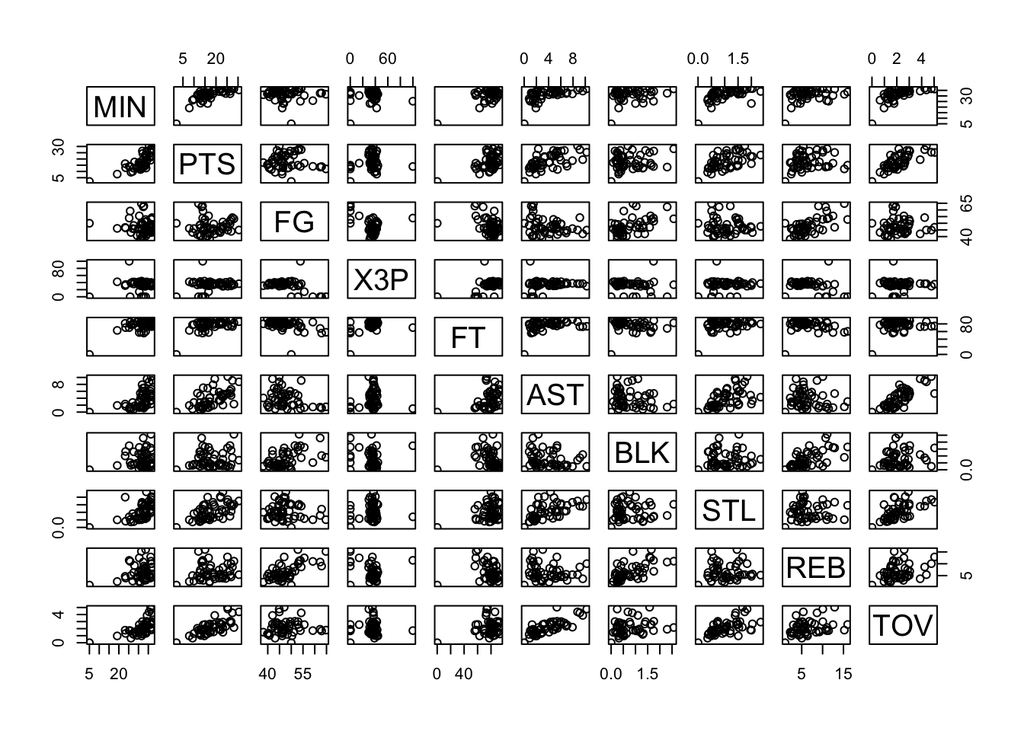

```r
plot(nbatable[5:14])
```

From the plots above it appears that PTS, FG, STL, REB, AST and TOV seem to have some linear relationship but we can’t for sure tell until we delve into the data. On the other hand, X3P and FT seem to have a non linear relationship but we can’t for sure tell until we delve into the data.

##Anova Summary

With that said, we can also estimate the MLR mode with R

```r
summary(nbamodel)
```

```
##
## Call:
## lm(formula = y ~ MIN + PTS + FG + X3P + FT + AST + BLK + STL +
##     REB + TOV, data = nbatable)
##
## Residuals:
##     Min      1Q  Median      3Q     Max
## -20.982  -2.615   1.089   3.576  20.484
##
## Coefficients:
##             Estimate Std. Error t value Pr(>|t|)
## (Intercept) 40.02278   20.73769   1.930  0.06091 .
## MIN         -0.12378    0.47327  -0.262  0.79505
## PTS          1.29777    0.43403   2.990  0.00481 **
## FG          -0.10262    0.35750  -0.287  0.77560
## X3P          0.09138    0.10626   0.860  0.39504
## FT          -0.42077    0.15597  -2.698  0.01026 *
## AST          3.68111    1.28441   2.866  0.00667 **
## BLK         -2.47717    3.21536  -0.770  0.44569
## STL         -6.85806    3.38102  -2.028  0.04939 *
## REB          1.29576    0.74617   1.737  0.09036 .
## TOV         -8.84851    3.88827  -2.276  0.02844 *
## ---
## Signif. codes:  0 '***' 0.001 '**' 0.01 '*' 0.05 '.' 0.1 ' ' 1
##
## Residual standard error: 9.306 on 39 degrees of freedom
## Multiple R-squared:  0.3971, Adjusted R-squared:  0.2425
## F-statistic: 2.569 on 10 and 39 DF,  p-value: 0.01712
```

However, given this, we still have to find out what our best model is.

##General Linear F test

In order to find out what our best model is, we are going to come up with a hypothesis test for testing all the slope parameters are 0. But before we do that, we have to perform a general linear F test and Stepwise test.

We are going to start by fitting the full model of data and then determine the SSE.

```r
anova(nbamodel)
```

|  | Df | Sum Sq | Mean Sq | F value | Pr(>F) |
| --- | --- | --- | --- | --- | --- |
| MIN | 1 | 1.439312 | 1.439312 | 0.01661979 | 0.89808529 |
| PTS | 1 | 470.809406 | 470.809406 | 5.43645115 | 0.02497926 |
| FG | 1 | 9.721218 | 9.721218 | 0.11225121 | 0.73939103 |
| X3P | 1 | 6.014550 | 6.014550 | 0.06945019 | 0.79352644 |
| FT | 1 | 382.830963 | 382.830963 | 4.42056127 | 0.04201427 |
| AST | 1 | 186.626645 | 186.626645 | 2.15498379 | 0.15012745 |
| BLK | 1 | 121.269996 | 121.269996 | 1.40030849 | 0.24383516 |
| STL | 1 | 564.566846 | 564.566846 | 6.51907128 | 0.01469700 |
| REB | 1 | 32.914847 | 32.914847 | 0.38006878 | 0.54114862 |
| TOV | 1 | 448.494843 | 448.494843 | 5.17878418 | 0.02843747 |

[output cut: 1 more lines]

Next, we will fit a reduced model of data and then determine the SSE. By just looking at the ANOVA table above, I will remove predictors with SSR of less than 100 just because they are not signficant enough. Therefore the predictors I am going to use are PTS, FT, AST, BLK, STL and TOV.

```r
nbamodelred <- lm(y ~ PTS + FT + AST + BLK + STL + TOV, data = nbatable)
anova(nbamodelred)
```

|  | Df | Sum Sq | Mean Sq | F value | Pr(>F) |
| --- | --- | --- | --- | --- | --- |
| PTS | 1 | 186.6648 | 186.66485 | 2.164763 | 0.14848745 |
| FT | 1 | 575.8544 | 575.85440 | 6.678216 | 0.01323919 |
| AST | 1 | 182.6607 | 182.66067 | 2.118326 | 0.15280793 |
| BLK | 1 | 127.1020 | 127.10199 | 1.474009 | 0.23134028 |
| STL | 1 | 590.4978 | 590.49777 | 6.848036 | 0.01219738 |
| TOV | 1 | 231.5628 | 231.56278 | 2.685447 | 0.10856635 |
| Residuals | 43 | 3707.8375 | 86.22878 | NA | NA |

Therefore given this, it would make sense for us to use the reduced model because the variation around the estimated full model regression function is almost as large as the variation around the estimated reduced model regression function.

We can also cross check this by performing a step wise model evaluation and see if this corresponds accordingly.

```r
best <- step(nbamodel, direction = "both")
```

```
## Start:  AIC=232.64
## y ~ MIN + PTS + FG + X3P + FT + AST + BLK + STL + REB + TOV
##
##        Df Sum of Sq    RSS    AIC
## - MIN   1      5.92 3383.4 230.73
## - FG    1      7.14 3384.6 230.75
## - BLK   1     51.40 3428.9 231.40
## - X3P   1     64.05 3441.5 231.58
## <none>              3377.5 232.64
## - REB   1    261.16 3638.7 234.37
## - STL   1    356.32 3733.8 235.66
## - TOV   1    448.49 3826.0 236.88
## - FT    1    630.26 4007.8 239.20
## - AST   1    711.34 4088.8 240.20
## - PTS   1    774.27 4151.8 240.96
##
## Step:  AIC=230.73
## y ~ PTS + FG + X3P + FT + AST + BLK + STL + REB + TOV
##
##        Df Sum of Sq    RSS    AIC
## - FG    1      5.46 3388.9 228.81
## - BLK   1     56.14 3439.6 229.55
## - X3P   1     80.13 3463.5 229.90
## <none>              3383.4 230.73
## - REB   1    260.12 3643.5 232.43
## + MIN   1      5.92 3377.5 232.64
## - STL   1    388.94 3772.4 234.17
## - TOV   1    445.90 3829.3 234.92
## - AST   1    708.32 4091.7 238.24
## - PTS   1    819.22 4202.6 239.57
## - FT    1    947.34 4330.8 241.07
##
## Step:  AIC=228.81
## y ~ PTS + X3P + FT + AST + BLK + STL + REB + TOV
##
##        Df Sum of Sq    RSS    AIC
## - BLK   1     67.20 3456.1 227.79
## - X3P   1     98.03 3486.9 228.24
## <none>              3388.9 228.81
## + FG    1      5.46 3383.4 230.73
```

[output cut: 24 more lines]

```
## Step:  AIC=226.88
## y ~ PTS + FT + AST + STL + REB + TOV
##
##        Df Sum of Sq    RSS    AIC
## <none>              3531.8 226.88
## - REB   1    177.74 3709.5 227.33
## + X3P   1     75.72 3456.1 227.79
## + BLK   1     44.89 3486.9 228.24
## + FG    1     35.05 3496.7 228.38
## + MIN   1     21.01 3510.8 228.58
## - STL   1    415.03 3946.8 230.43
## - TOV   1    508.21 4040.0 231.60
## - PTS   1    787.49 4319.3 234.94
## - FT    1    892.61 4424.4 236.14
## - AST   1    893.97 4425.8 236.16
```

Next, we will look at the remaining predictors and see if any warrant investigation based off of corelation.

```r
vifred <- vif(nbamodelred)
vifred
```

```
##      PTS       FT      AST      BLK      STL      TOV
## 3.251616 1.603956 4.632193 1.653394 1.719510 6.253296
```

##Sequential Sum of Squares

Moving on with the reduced model, we are going to try and find out the sequential sum of squares of the reduced model.

The Sequential sum of squares can be thought of as:

1. The reduction in the error sum of squares (SSE) when one or more predictor variables are added to the model.
2. The increase in the regression sum of squares (SSR) when one or more predictor variables are added to the model.

```r
anova(lm(y ~ PTS, data = nbatable))
```

|  | Df | Sum Sq | Mean Sq | F value | Pr(>F) |
| --- | --- | --- | --- | --- | --- |
| PTS | 1 | 186.6648 | 186.6648 | 1.654489 | 0.2045189 |
| Residuals | 48 | 5415.5152 | 112.8232 | NA | NA |

Looking at the table above, with an SSR of 186, we can conclude that a large majority of the model with PTS as the only predictor will be explained by Error.

Let’s add AST to the model and see if the SSR or SSE changes. We can denote this by:

SSR (AST | PTS)

```r
anova(lm(y ~ AST * PTS, data = nbatable))
```

|  | Df | Sum Sq | Mean Sq | F value | Pr(>F) |
| --- | --- | --- | --- | --- | --- |
| AST | 1 | 332.14441 | 332.14441 | 3.19925230 | 0.08025857 |
| PTS | 1 | 10.23043 | 10.23043 | 0.09854066 | 0.75500717 |
| AST:PTS | 1 | 484.11345 | 484.11345 | 4.66303522 | 0.03606744 |
| Residuals | 46 | 4775.69171 | 103.81939 | NA | NA |

```r
anova(lm(y ~ PTS * AST, data = nbatable))
```

|  | Df | Sum Sq | Mean Sq | F value | Pr(>F) |
| --- | --- | --- | --- | --- | --- |
| PTS | 1 | 186.6648 | 186.6648 | 1.797977 | 0.18654141 |
| AST | 1 | 155.7100 | 155.7100 | 1.499816 | 0.22693438 |
| PTS:AST | 1 | 484.1134 | 484.1134 | 4.663035 | 0.03606744 |
| Residuals | 46 | 4775.6917 | 103.8194 | NA | NA |

```r
anova(lm(y ~ PTS * AST * FT, data = nbatable))
```

|  | Df | Sum Sq | Mean Sq | F value | Pr(>F) |
| --- | --- | --- | --- | --- | --- |
| PTS | 1 | 186.66485 | 186.66485 | 1.8002365 | 0.18689344 |
| AST | 1 | 155.70999 | 155.70999 | 1.5017012 | 0.22723747 |
| FT | 1 | 602.80508 | 602.80508 | 5.8135838 | 0.02035538 |
| PTS:AST | 1 | 96.60828 | 96.60828 | 0.9317114 | 0.33994390 |
| PTS:FT | 1 | 76.56445 | 76.56445 | 0.7384043 | 0.39505071 |
| AST:FT | 1 | 110.42315 | 110.42315 | 1.0649450 | 0.30799612 |
| PTS:AST:FT | 1 | 18.46340 | 18.46340 | 0.1780650 | 0.67519364 |
| Residuals | 42 | 4354.94080 | 103.68907 | NA | NA |

##Influential Points

If an observation has a response value that is very different from the predicted value based on a model, then that observation is called an outlier. On the other hand, if an observation has a particularly unusual combination of predictor values (e.g., one predictor has a very different value for that observation compared with all the other data observations), then that observation is said to have high leverage.

I can do furthur analysis to investigate whether or not this point is influential or not.

```r
res_nbamodel <- nbamodelred$residuals
est <- summary(nbamodelred)
#names(est)
MSres <- est$sigma
standard_residuals <-residuals(nbamodelred)/MSres
hatvalues_matrix <- hatvalues(nbamodelred)
hat2  <-1-hatvalues(nbamodelred)
r_std <- rstandard(nbamodelred)
r_stud <- rstudent(nbamodelred)
res_press <-residuals(nbamodelred)/hat2
res_press_sq<-res_press^2

Residual_Delivery<-round(cbind(residuals(nbamodelred),residuals(nbamodelred)/MSres,rstandard(nbamodelred),hatvalues(nbamodelred),residuals(nbamodelred)/hat2,rstudent(nbamodelred),res_press^2),4)

model_fit <- nbamodelred$fitted.values

Residual_Delivery <- cbind(model_fit,Residual_Delivery)
colnames(Residual_Delivery)<-c("fitted val","residuals","stand_resid","rstand","hat","PRESS","rstudent","Press_Squared")
pander(Residual_Delivery, split.table = Inf, caption ="Matrix with all the types of residual errors")
```

Matrix with all the types of residual errors

| fitted val | residuals | stand_resid | rstand | hat | PRESS | rstudent | Press_Squared |
| --- | --- | --- | --- | --- | --- | --- | --- |
| 21.37 | 16.63 | 1.79 | 1.885 | 0.0978 | 18.43 | 1.945 | 339.6 |
| 32.16 | 4.835 | 0.5207 | 0.568 | 0.1595 | 5.753 | 0.5635 | 33.1 |
| 16.6 | 19.4 | 2.089 | 2.134 | 0.0413 | 20.24 | 2.23 | 409.6 |
| 27.17 | 7.827 | 0.8428 | 0.8867 | 0.0964 | 8.661 | 0.8844 | 75.02 |
| 39.52 | -4.523 | -0.4871 | -0.9886 | 0.7572 | -18.63 | -0.9883 | 347.1 |
| 21.43 | 12.57 | 1.354 | 1.427 | 0.0996 | 13.96 | 1.444 | 194.9 |
| 22.05 | 10.95 | 1.179 | 1.213 | 0.0548 | 11.58 | 1.22 | 134.2 |
| 26.66 | 6.339 | 0.6827 | 0.7753 | 0.2246 | 8.176 | 0.7716 | 66.84 |
| 26.58 | 5.425 | 0.5842 | 0.6281 | 0.1348 | 6.27 | 0.6236 | 39.31 |
| 26.93 | 4.071 | 0.4384 | 0.4566 | 0.0783 | 4.417 | 0.4524 | 19.51 |
| 20.61 | 9.395 | 1.012 | 1.084 | 0.1287 | 10.78 | 1.086 | 116.3 |
| 19.09 | 9.912 | 1.067 | 1.099 | 0.0566 | 10.51 | 1.102 | 110.4 |
| 28.24 | -0.2435 | -0.0262 | -0.0278 | 0.1129 | -0.2745 | -0.0275 | 0.0754 |
| 19.89 | 7.11 | 0.7656 | 0.7877 | 0.0553 | 7.526 | 0.7842 | 56.63 |
| 26.21 | -0.2085 | -0.0225 | -0.0248 | 0.1791 | -0.254 | -0.0245 | 0.0645 |
| 11.78 | 13.22 | 1.424 | 1.523 | 0.1258 | 15.12 | 1.547 | 228.7 |
| 20.89 | 3.114 | 0.3354 | 0.3731 | 0.192 | 3.854 | 0.3693 | 14.86 |
| 22.15 | 0.8525 | 0.0918 | 0.0947 | 0.0599 | 0.9068 | 0.0936 | 0.8223 |
| 22.82 | -0.815 | -0.0878 | -0.0903 | 0.0548 | -0.8623 | -0.0892 | 0.7435 |
| 20.67 | 1.327 | 0.1429 | 0.1829 | 0.3896 | 2.175 | 0.1809 | 4.728 |
| 14.45 | 7.553 | 0.8134 | 0.8717 | 0.1293 | 8.675 | 0.8692 | 75.25 |
| 14.53 | 7.471 | 0.8045 | 0.8458 | 0.0951 | 8.256 | 0.8429 | 68.16 |
| 19.7 | 1.305 | 0.1405 | 0.153 | 0.157 | 1.548 | 0.1513 | 2.395 |
| 20.19 | -0.1948 | -0.021 | -0.0222 | 0.1038 | -0.2174 | -0.0219 | 0.0472 |
| 18.82 | 1.181 | 0.1272 | 0.1331 | 0.0871 | 1.294 | 0.1316 | 1.674 |
| 19.5 | -0.5016 | -0.054 | -0.057 | 0.1006 | -0.5577 | -0.0563 | 0.311 |
| 15.44 | 2.556 | 0.2753 | 0.2877 | 0.0845 | 2.792 | 0.2846 | 7.796 |
| 19.81 | -1.807 | -0.1946 | -0.2027 | 0.0777 | -1.96 | -0.2004 | 3.841 |
| 16.74 | 1.262 | 0.1359 | 0.1428 | 0.0944 | 1.394 | 0.1412 | 1.942 |
| 19.72 | -1.723 | -0.1855 | -0.194 | 0.0858 | -1.884 | -0.1918 | 3.551 |
| 25.02 | -8.02 | -0.8636 | -0.9135 | 0.1062 | -8.972 | -0.9117 | 80.5 |
| 16.84 | 0.159 | 0.0171 | 0.0181 | 0.1062 | 0.1779 | 0.0179 | 0.0316 |
| 15.2 | 0.7971 | 0.0858 | 0.0916 | 0.1213 | 0.9071 | 0.0905 | 0.8228 |
| 14.01 | 0.9906 | 0.1067 | 0.1183 | 0.1863 | 1.217 | 0.1169 | 1.482 |
| 25.24 | -11.24 | -1.211 | -1.315 | 0.153 | -13.27 | -1.327 | 176.2 |
| 11.68 | 1.324 | 0.1426 | 0.159 | 0.1951 | 1.645 | 0.1571 | 2.707 |
| 12.49 | -0.4921 | -0.053 | -0.0568 | 0.1285 | -0.5647 | -0.0561 | 0.3188 |
| 14.26 | -3.257 | -0.3507 | -0.3681 | 0.0926 | -3.589 | -0.3644 | 12.88 |
| 14.51 | -4.508 | -0.4855 | -0.5098 | 0.093 | -4.97 | -0.5053 | 24.7 |
| 12.69 | -3.688 | -0.3972 | -0.4145 | 0.0819 | -4.017 | -0.4105 | 16.13 |
| 15.17 | -7.174 | -0.7726 | -0.8107 | 0.0919 | -7.9 | -0.8074 | 62.41 |
| 10.64 | -3.638 | -0.3918 | -0.4334 | 0.1828 | -4.452 | -0.4293 | 19.82 |
| 14.24 | -8.24 | -0.8873 | -0.9195 | 0.0688 | -8.848 | -0.9178 | 78.29 |
| 18.87 | -13.87 | -1.494 | -1.64 | 0.1709 | -16.73 | -1.674 | 279.8 |
| 16.01 | -12.01 | -1.293 | -1.396 | 0.1421 | -14 | -1.412 | 196 |
| 24.99 | -21.99 | -2.368 | -2.472 | 0.0825 | -23.97 | -2.638 | 574.4 |
| 6.501 | -3.501 | -0.377 | -0.4175 | 0.1843 | -4.292 | -0.4134 | 18.42 |
| 26.37 | -24.37 | -2.624 | -2.981 | 0.2251 | -31.45 | -3.308 | 988.9 |
| 12.51 | -10.51 | -1.132 | -1.454 | 0.3941 | -17.34 | -1.474 | 300.8 |
| 12.05 | -11.05 | -1.19 | -1.24 | 0.0792 | -12 | -1.248 | 144.1 |

```r
infnbamodel <- influence.measures(nbamodelred)
pander(infnbamodel$infmat)
```

Table continues below

| dfb.1_ | dfb.PTS | dfb.FT | dfb.AST | dfb.BLK | dfb.STL |
| --- | --- | --- | --- | --- | --- |
| -0.1375 | 0.2519 | 0.04159 | -0.1653 | -0.3699 | 0.0633 |
| 0.04244 | 0.07117 | -0.1029 | 0.09544 | 0.01669 | -0.06913 |
| 0.1332 | -0.1703 | -0.03343 | -0.01546 | 0.1781 | 0.1118 |
| 0.04577 | 0.06246 | -0.02505 | -0.007938 | -0.1294 | -0.1996 |
| -1.737 | -0.4314 | 1.509 | -0.2751 | 0.3016 | 0.08713 |
| -0.001314 | -0.181 | 0.1152 | 0.2941 | 0.03316 | -0.05457 |
| 0.0858 | 0.08456 | -0.03792 | 0.1211 | -0.03709 | 0.01292 |
| 0.05161 | -0.06423 | -0.08476 | 0.01629 | -0.1461 | 0.003347 |
| -0.03762 | 0.07659 | -0.03781 | 0.005525 | -0.04966 | -0.0195 |
| 0.02502 | 0.09289 | -0.03955 | 0.03619 | -0.03231 | -0.02931 |
| 0.01109 | -0.1575 | 0.08901 | 0.2787 | 0.2566 | -0.1351 |
| 0.05705 | 0.08532 | 0.005171 | -0.1064 | -0.0826 | -0.08307 |
| 0.001209 | -0.006182 | 0.0005207 | -0.002635 | 0.001582 | 0.004166 |
| 0.01465 | -0.03808 | -0.01638 | 0.1028 | 0.06424 | 0.08146 |
| 0.003336 | -0.004186 | -0.001025 | -0.003925 | -0.006534 | 0.00638 |
| 0.01082 | -0.026 | 0.05863 | 0.003494 | 0.02769 | 0.4324 |
| -0.01255 | -0.02268 | 0.01914 | 0.134 | 0.05041 | 0.05737 |
| 0.001214 | 0.01508 | -0.001677 | -0.004496 | -0.009333 | -0.004874 |
| -0.003082 | -0.01058 | 0.004896 | 0.007344 | 0.01252 | 0.002562 |
| -0.02188 | 0.07595 | -0.02568 | 0.03349 | 0.1009 | 0.03013 |
| 0.07877 | -0.1263 | -0.07213 | -0.03166 | 0.134 | 0.1611 |
| 0.004324 | -0.06797 | 0.03602 | -0.04001 | 0.1538 | -0.02182 |
| 0.01805 | -0.002021 | -0.01447 | -0.03288 | 0.0001422 | -0.02079 |
| -0.0005033 | -0.002749 | -0.0006604 | 0.003846 | 0.004872 | 0.002532 |
| 0.02631 | -0.01632 | -0.005224 | 0.001215 | -0.009351 | -0.004553 |
| 0.002341 | -0.001577 | -0.007786 | 0.003872 | 0.009023 | 0.009683 |
| -0.01727 | 0.006232 | 0.03788 | -0.05197 | -0.0446 | -0.02026 |
| -0.0139 | 0.003895 | 0.000173 | -0.01563 | -0.03333 | 0.02329 |
| -0.01492 | -0.02117 | 0.02284 | 0.001411 | 0.01831 | -0.02036 |
| -0.03454 | 0.01257 | 0.01613 | 0.02346 | 0.01284 | 0.01759 |
| -0.01582 | -0.2166 | 0.1403 | -0.03921 | -0.1052 | -0.02757 |
| 0.003626 | 3.784e-05 | -0.003143 | -0.002263 | -0.0004745 | 0.003045 |
| -0.001619 | -0.02569 | 0.01492 | 0.01045 | 0.001613 | 0.0008204 |
| -0.001642 | -0.01586 | 0.004929 | 0.007476 | 0.04462 | 0.0004198 |
| 0.014 | -0.4226 | 0.07032 | -0.07167 | -0.1526 | 0.2185 |
| -0.005219 | 0.000254 | -0.006308 | -0.03071 | -0.01659 | 0.06506 |
| 0.004169 | 0.007999 | -0.01205 | 0.01416 | 0.00994 | 0.007497 |
| 0.03941 | 0.01923 | -0.07917 | 0.02877 | 0.02196 | 0.03795 |
| 0.02044 | 0.04246 | -0.07056 | 0.0134 | -0.06357 | 0.05833 |
| -0.009958 | 0.08755 | -0.05159 | 0.003063 | 0.01324 | -0.02433 |
| -0.04685 | 0.08427 | -0.08849 | 0.04878 | 0.06747 | 0.06408 |
| 0.02084 | 0.005509 | -0.01009 | 0.132 | 0.0971 | -0.1377 |
| 0.02666 | 0.0593 | -0.1335 | 0.06432 | 0.05263 | 0.03869 |
| -0.03427 | -0.2669 | 0.1511 | -0.203 | -0.04547 | -0.5307 |
| 0.0365 | 0.3833 | -0.1798 | -0.2471 | -0.05682 | -0.1518 |
| 0.0464 | -0.5232 | 0.0442 | -0.04119 | 0.2758 | 0.2119 |
| 0.02496 | 0.05201 | -0.03033 | 0.04413 | -0.02109 | -0.1754 |
| -0.1673 | 0.5899 | 0.1836 | -1.187 | -0.777 | 0.1753 |
| 0.2431 | 0.3696 | -0.1776 | 0.7651 | 0.2769 | -0.004042 |
| -0.007129 | 0.1682 | -0.13 | 0.06962 | 0.1087 | -0.1801 |

| dfb.TOV | dffit | cov.r | cook.d | hat |
| --- | --- | --- | --- | --- |
| 0.08683 | 0.6403 | 0.7145 | 0.05502 | 0.09778 |
| -0.001539 | 0.2455 | 1.331 | 0.008747 | 0.1595 |
| 0.02435 | 0.4631 | 0.5618 | 0.02804 | 0.04133 |
| 0.08692 | 0.2889 | 1.147 | 0.01198 | 0.09639 |
| 0.4364 | -1.745 | 4.135 | 0.4355 | 0.7572 |
| -0.0883 | 0.4806 | 0.9326 | 0.03218 | 0.09965 |
| -0.1712 | 0.2938 | 0.9777 | 0.01219 | 0.05483 |
| 0.1742 | 0.4153 | 1.378 | 0.02487 | 0.2246 |
| 0.053 | 0.2461 | 1.278 | 0.008779 | 0.1348 |
| -0.0572 | 0.1319 | 1.236 | 0.002531 | 0.07831 |
| -0.1226 | 0.4174 | 1.115 | 0.02478 | 0.1287 |
| 0.005448 | 0.2698 | 1.024 | 0.01035 | 0.05659 |
| 0.002552 | -0.009819 | 1.329 | 1.41e-05 | 0.1129 |
| -0.05999 | 0.1896 | 1.127 | 0.005184 | 0.05525 |
| 0.002418 | -0.01144 | 1.436 | 1.915e-05 | 0.1791 |
| -0.2444 | 0.5868 | 0.9149 | 0.04765 | 0.1258 |
| -0.1043 | 0.18 | 1.426 | 0.004726 | 0.192 |
| -0.003867 | 0.02362 | 1.252 | 8.158e-05 | 0.05988 |
| -0.004269 | -0.02149 | 1.246 | 6.753e-05 | 0.05482 |
| -0.08114 | 0.1445 | 1.921 | 0.003052 | 0.3896 |
| 0.0546 | 0.3349 | 1.195 | 0.01612 | 0.1293 |
| 0.02875 | 0.2733 | 1.159 | 0.01074 | 0.09511 |
| 0.03549 | 0.06527 | 1.393 | 0.0006228 | 0.157 |
| -0.001577 | -0.007455 | 1.316 | 8.128e-06 | 0.1038 |
| 0.001756 | 0.04066 | 1.288 | 0.0002417 | 0.08714 |
| -0.002642 | -0.01882 | 1.31 | 5.183e-05 | 0.1006 |
| 0.02864 | 0.08649 | 1.271 | 0.001092 | 0.08454 |
| 0.0146 | -0.05817 | 1.27 | 0.0004945 | 0.07771 |
| 0.01645 | 0.04558 | 1.298 | 0.0003037 | 0.09439 |
| -0.02732 | -0.05878 | 1.282 | 0.0005049 | 0.08582 |
| 0.1035 | -0.3142 | 1.15 | 0.01416 | 0.1062 |
| 0.0004569 | 0.006169 | 1.319 | 5.567e-06 | 0.1062 |
| 0.003924 | 0.03362 | 1.34 | 0.0001653 | 0.1213 |
| -0.00381 | 0.05592 | 1.446 | 0.0004573 | 0.1863 |
| 0.27 | -0.5639 | 1.044 | 0.04464 | 0.153 |
| 0.01028 | 0.07737 | 1.459 | 0.0008749 | 0.1951 |
| -0.0146 | -0.02154 | 1.352 | 6.786e-05 | 0.1285 |
| -0.01584 | -0.1164 | 1.271 | 0.001975 | 0.09255 |
| -0.006818 | -0.1618 | 1.246 | 0.003807 | 0.09301 |
| -0.01672 | -0.1226 | 1.249 | 0.002188 | 0.08185 |
| -0.02474 | -0.2569 | 1.166 | 0.009502 | 0.0919 |
| -0.07269 | -0.203 | 1.399 | 0.006002 | 0.1828 |
| -0.0193 | -0.2494 | 1.102 | 0.008918 | 0.06876 |
| 0.4729 | -0.7602 | 0.9046 | 0.07923 | 0.1709 |
| 0.006725 | -0.5748 | 0.9933 | 0.04614 | 0.1421 |
| 0.1842 | -0.7908 | 0.4393 | 0.07847 | 0.08245 |
| 0.0125 | -0.1965 | 1.405 | 0.005624 | 0.1843 |
| 0.1459 | -1.783 | 0.3009 | 0.3687 | 0.2251 |
| -1.034 | -1.188 | 1.367 | 0.1964 | 0.3941 |
| -0.01771 | -0.3662 | 0.9923 | 0.01891 | 0.07923 |

```r
pander(infnbamodel$is.inf)
```

Table continues below

| dfb.1_ | dfb.PTS | dfb.FT | dfb.AST | dfb.BLK | dfb.STL | dfb.TOV | dffit |
| --- | --- | --- | --- | --- | --- | --- | --- |
| FALSE | FALSE | FALSE | FALSE | FALSE | FALSE | FALSE | FALSE |
| FALSE | FALSE | FALSE | FALSE | FALSE | FALSE | FALSE | FALSE |
| FALSE | FALSE | FALSE | FALSE | FALSE | FALSE | FALSE | FALSE |
| FALSE | FALSE | FALSE | FALSE | FALSE | FALSE | FALSE | FALSE |
| TRUE | FALSE | TRUE | FALSE | FALSE | FALSE | FALSE | TRUE |
| FALSE | FALSE | FALSE | FALSE | FALSE | FALSE | FALSE | FALSE |
| FALSE | FALSE | FALSE | FALSE | FALSE | FALSE | FALSE | FALSE |
| FALSE | FALSE | FALSE | FALSE | FALSE | FALSE | FALSE | FALSE |
| FALSE | FALSE | FALSE | FALSE | FALSE | FALSE | FALSE | FALSE |
| FALSE | FALSE | FALSE | FALSE | FALSE | FALSE | FALSE | FALSE |
| FALSE | FALSE | FALSE | FALSE | FALSE | FALSE | FALSE | FALSE |
| FALSE | FALSE | FALSE | FALSE | FALSE | FALSE | FALSE | FALSE |
| FALSE | FALSE | FALSE | FALSE | FALSE | FALSE | FALSE | FALSE |
| FALSE | FALSE | FALSE | FALSE | FALSE | FALSE | FALSE | FALSE |
| FALSE | FALSE | FALSE | FALSE | FALSE | FALSE | FALSE | FALSE |
| FALSE | FALSE | FALSE | FALSE | FALSE | FALSE | FALSE | FALSE |
| FALSE | FALSE | FALSE | FALSE | FALSE | FALSE | FALSE | FALSE |
| FALSE | FALSE | FALSE | FALSE | FALSE | FALSE | FALSE | FALSE |
| FALSE | FALSE | FALSE | FALSE | FALSE | FALSE | FALSE | FALSE |
| FALSE | FALSE | FALSE | FALSE | FALSE | FALSE | FALSE | FALSE |
| FALSE | FALSE | FALSE | FALSE | FALSE | FALSE | FALSE | FALSE |
| FALSE | FALSE | FALSE | FALSE | FALSE | FALSE | FALSE | FALSE |
| FALSE | FALSE | FALSE | FALSE | FALSE | FALSE | FALSE | FALSE |
| FALSE | FALSE | FALSE | FALSE | FALSE | FALSE | FALSE | FALSE |
| FALSE | FALSE | FALSE | FALSE | FALSE | FALSE | FALSE | FALSE |
| FALSE | FALSE | FALSE | FALSE | FALSE | FALSE | FALSE | FALSE |
| FALSE | FALSE | FALSE | FALSE | FALSE | FALSE | FALSE | FALSE |
| FALSE | FALSE | FALSE | FALSE | FALSE | FALSE | FALSE | FALSE |
| FALSE | FALSE | FALSE | FALSE | FALSE | FALSE | FALSE | FALSE |
| FALSE | FALSE | FALSE | FALSE | FALSE | FALSE | FALSE | FALSE |
| FALSE | FALSE | FALSE | FALSE | FALSE | FALSE | FALSE | FALSE |
| FALSE | FALSE | FALSE | FALSE | FALSE | FALSE | FALSE | FALSE |
| FALSE | FALSE | FALSE | FALSE | FALSE | FALSE | FALSE | FALSE |
| FALSE | FALSE | FALSE | FALSE | FALSE | FALSE | FALSE | FALSE |
| FALSE | FALSE | FALSE | FALSE | FALSE | FALSE | FALSE | FALSE |
| FALSE | FALSE | FALSE | FALSE | FALSE | FALSE | FALSE | FALSE |
| FALSE | FALSE | FALSE | FALSE | FALSE | FALSE | FALSE | FALSE |
| FALSE | FALSE | FALSE | FALSE | FALSE | FALSE | FALSE | FALSE |
| FALSE | FALSE | FALSE | FALSE | FALSE | FALSE | FALSE | FALSE |
| FALSE | FALSE | FALSE | FALSE | FALSE | FALSE | FALSE | FALSE |
| FALSE | FALSE | FALSE | FALSE | FALSE | FALSE | FALSE | FALSE |
| FALSE | FALSE | FALSE | FALSE | FALSE | FALSE | FALSE | FALSE |
| FALSE | FALSE | FALSE | FALSE | FALSE | FALSE | FALSE | FALSE |
| FALSE | FALSE | FALSE | FALSE | FALSE | FALSE | FALSE | FALSE |
| FALSE | FALSE | FALSE | FALSE | FALSE | FALSE | FALSE | FALSE |
| FALSE | FALSE | FALSE | FALSE | FALSE | FALSE | FALSE | FALSE |
| FALSE | FALSE | FALSE | FALSE | FALSE | FALSE | FALSE | FALSE |
| FALSE | FALSE | FALSE | TRUE | FALSE | FALSE | FALSE | TRUE |
| FALSE | FALSE | FALSE | FALSE | FALSE | FALSE | TRUE | FALSE |
| FALSE | FALSE | FALSE | FALSE | FALSE | FALSE | FALSE | FALSE |

| cov.r | cook.d | hat |
| --- | --- | --- |
| FALSE | FALSE | FALSE |
| FALSE | FALSE | FALSE |
| FALSE | FALSE | FALSE |
| FALSE | FALSE | FALSE |
| TRUE | FALSE | TRUE |
| FALSE | FALSE | FALSE |
| FALSE | FALSE | FALSE |
| FALSE | FALSE | FALSE |
| FALSE | FALSE | FALSE |
| FALSE | FALSE | FALSE |
| FALSE | FALSE | FALSE |
| FALSE | FALSE | FALSE |
| FALSE | FALSE | FALSE |
| FALSE | FALSE | FALSE |
| FALSE | FALSE | FALSE |
| FALSE | FALSE | FALSE |
| FALSE | FALSE | FALSE |
| FALSE | FALSE | FALSE |
| FALSE | FALSE | FALSE |
| TRUE | FALSE | FALSE |
| FALSE | FALSE | FALSE |
| FALSE | FALSE | FALSE |
| FALSE | FALSE | FALSE |
| FALSE | FALSE | FALSE |
| FALSE | FALSE | FALSE |
| FALSE | FALSE | FALSE |
| FALSE | FALSE | FALSE |
| FALSE | FALSE | FALSE |
| FALSE | FALSE | FALSE |
| FALSE | FALSE | FALSE |
| FALSE | FALSE | FALSE |
| FALSE | FALSE | FALSE |
| FALSE | FALSE | FALSE |
| FALSE | FALSE | FALSE |
| FALSE | FALSE | FALSE |
| FALSE | FALSE | FALSE |
| FALSE | FALSE | FALSE |
| FALSE | FALSE | FALSE |
| FALSE | FALSE | FALSE |
| FALSE | FALSE | FALSE |
| FALSE | FALSE | FALSE |
| FALSE | FALSE | FALSE |
| FALSE | FALSE | FALSE |
| FALSE | FALSE | FALSE |
| FALSE | FALSE | FALSE |
| TRUE | FALSE | FALSE |
| FALSE | FALSE | FALSE |
| TRUE | FALSE | FALSE |
| FALSE | FALSE | FALSE |
| FALSE | FALSE | FALSE |

```r
summary(infnbamodel)
```

```
## Potentially influential observations of
##   lm(formula = y ~ PTS + FT + AST + BLK + STL + TOV, data = nbatable) :
##
##    dfb.1_  dfb.PTS dfb.FT  dfb.AST dfb.BLK dfb.STL dfb.TOV dffit   cov.r
## 5  -1.74_* -0.43    1.51_* -0.28    0.30    0.09    0.44   -1.75_*  4.14_*
## 20 -0.02    0.08   -0.03    0.03    0.10    0.03   -0.08    0.14    1.92_*
## 46  0.05   -0.52    0.04   -0.04    0.28    0.21    0.18   -0.79    0.44_*
## 48 -0.17    0.59    0.18   -1.19_* -0.78    0.18    0.15   -1.78_*  0.30_*
## 49  0.24    0.37   -0.18    0.77    0.28    0.00   -1.03_* -1.19    1.37
##    cook.d hat
## 5   0.44   0.76_*
## 20  0.00   0.39
## 46  0.08   0.08
## 48  0.37   0.23
## 49  0.20   0.39
```

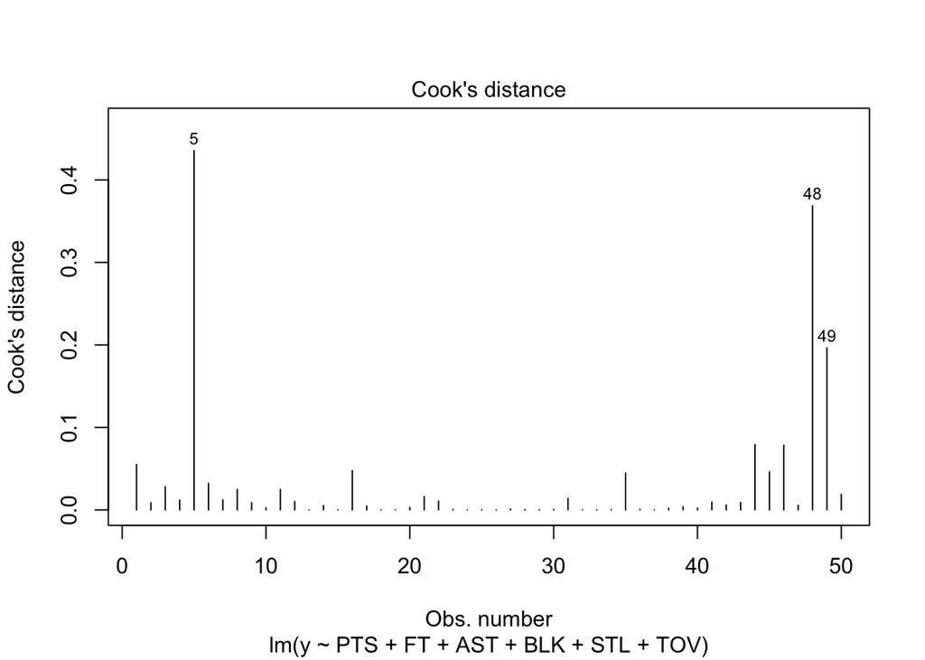

```r
plot(nbamodelred, which = c(4))
```

```r
nbacooks <- rev(sort(round(cooks.distance(nbamodelred), 5)))
nbacooks
```

```
##       5      48      49      44      46       1      16      45      35       6
## 0.43548 0.36870 0.19642 0.07923 0.07847 0.05502 0.04765 0.04614 0.04464 0.03218
##       3       8      11      50      21      31       7       4      22      12
## 0.02804 0.02487 0.02478 0.01891 0.01612 0.01416 0.01219 0.01198 0.01074 0.01035
##      41      43       9       2      42      47      14      17      39      20
## 0.00950 0.00892 0.00878 0.00875 0.00600 0.00562 0.00518 0.00473 0.00381 0.00305
##      10      40      38      27      36      23      30      28      34      29
## 0.00253 0.00219 0.00197 0.00109 0.00087 0.00062 0.00050 0.00049 0.00046 0.00030
##      25      33      18      37      19      26      15      32      24      13
## 0.00024 0.00017 0.00008 0.00007 0.00007 0.00005 0.00002 0.00001 0.00001 0.00001
```

From the Cook’s distance analysis from above, point 5 which is our highest point with 0.43548 is worthy of investigation but since its below 0.5, it is still not an influential point.

##Hypothesis Testing

So to this point, we have come up with our reduced model, now we are going to test the hypothesis that all the slope parameters are equal to 0. Thus, our null and alternative hypothesis can be seen below:

H0: B1 = B2 = B3 = B4 = B5 = B6 = 0

HA: Bi (for i = 1,2,3,4,5,6) ≠ 0

To test the null hypothesis, we just use the overall F-test and P-value reported in the analysis of variance table:

```r
summary(nbamodelred)
```

```
##
## Call:
## lm(formula = y ~ PTS + FT + AST + BLK + STL + TOV, data = nbatable)
##
## Residuals:
##     Min      1Q  Median      3Q     Max
## -24.369  -3.675   0.478   5.278  19.401
##
## Coefficients:
##             Estimate Std. Error t value Pr(>|t|)
## (Intercept)  37.2237     7.9223   4.699  2.7e-05 ***
## PTS           1.1496     0.3956   2.906  0.00577 **
## FT           -0.3733     0.1166  -3.200  0.00258 **
## AST           2.6588     1.1251   2.363  0.02271 *
## BLK          -0.4010     2.8544  -0.140  0.88893
## STL          -7.6480     3.2888  -2.325  0.02483 *
## TOV          -5.2901     3.2281  -1.639  0.10857
## ---
## Signif. codes:  0 '***' 0.001 '**' 0.01 '*' 0.05 '.' 0.1 ' ' 1
##
## Residual standard error: 9.286 on 43 degrees of freedom
## Multiple R-squared:  0.3381, Adjusted R-squared:  0.2458
## F-statistic: 3.661 on 6 and 43 DF,  p-value: 0.005033
```

With a P value of 0.005033, There is sufficient evidence with an F value of 3.661 to conclude that at least one of the slope parameters is not equal to 0. Thus we can reject the null hypothesis and go with the alternative.

##Residual Plotting

We are perfomring all these to assess whether our predictors have a strong linear relationship with the model.

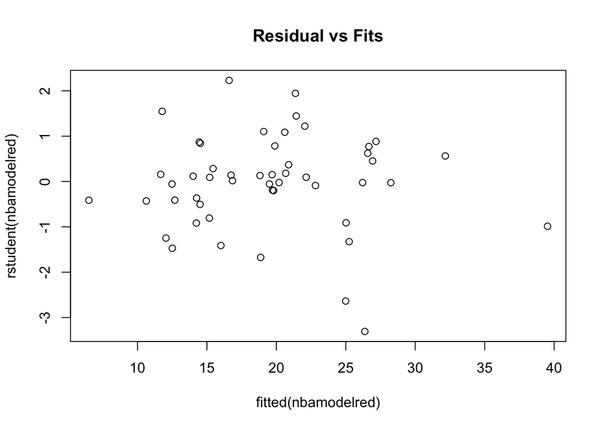

```r
plot(fitted(nbamodelred), rstudent(nbamodelred), main = "Residual vs Fits")
```

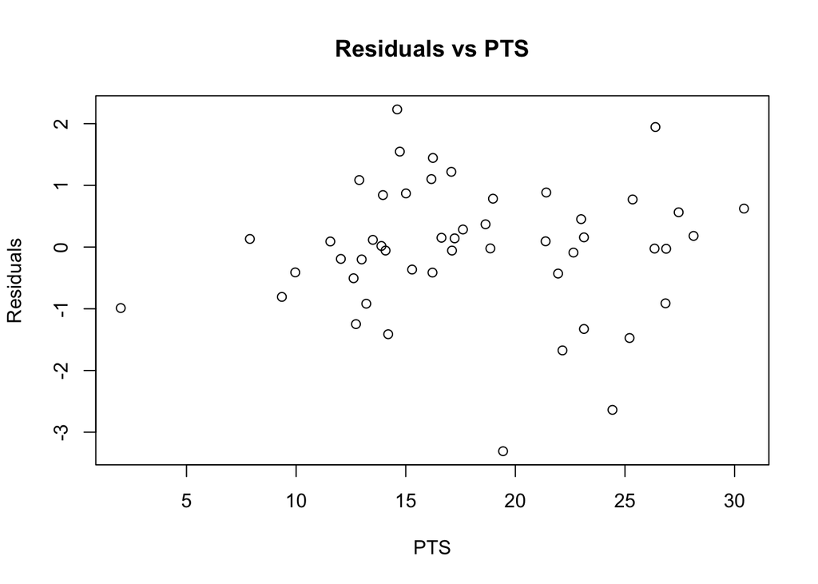

```r
plot(nbatable$PTS, rstudent(nbamodelred), main = "Residuals vs PTS", xlab = "PTS"
, ylab = "Residuals")
```

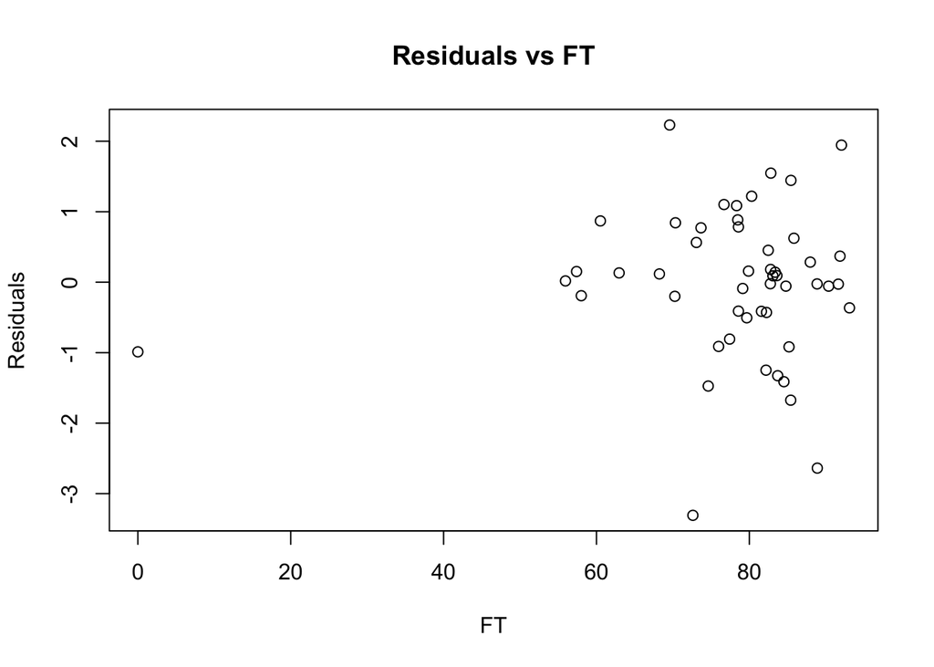

```r
plot(nbatable$FT, rstudent(nbamodelred), main = "Residuals vs FT", xlab = "FT"
, ylab = "Residuals")
```

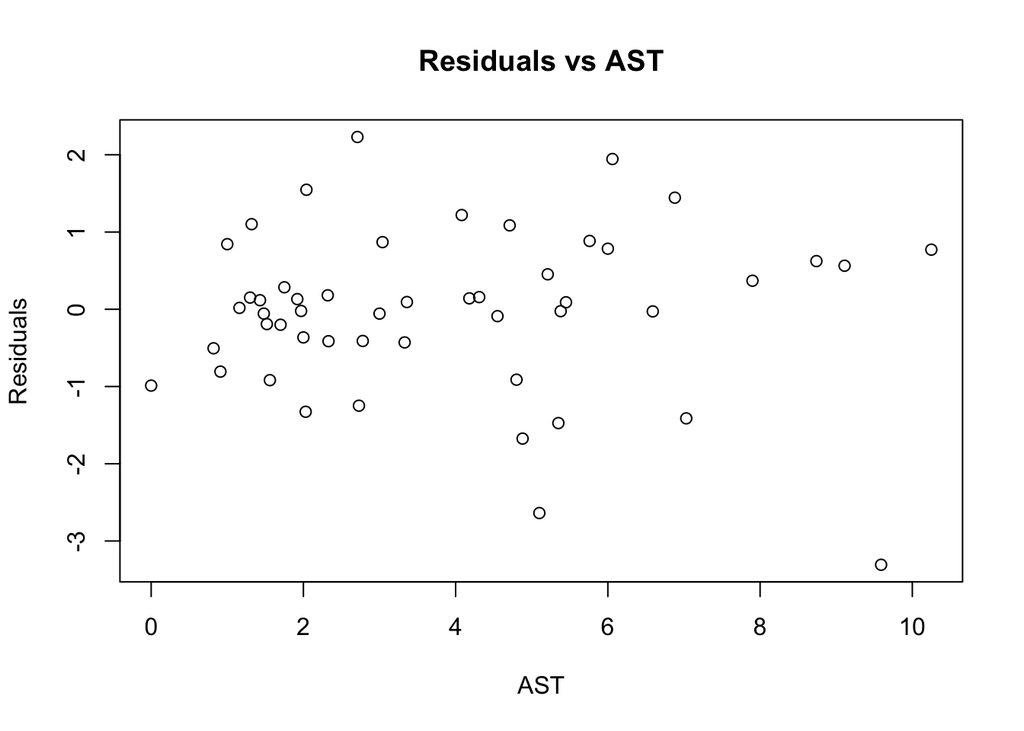

```r
plot(nbatable$AST, rstudent(nbamodelred), main = "Residuals vs AST", xlab = "AST"
, ylab = "Residuals")
```

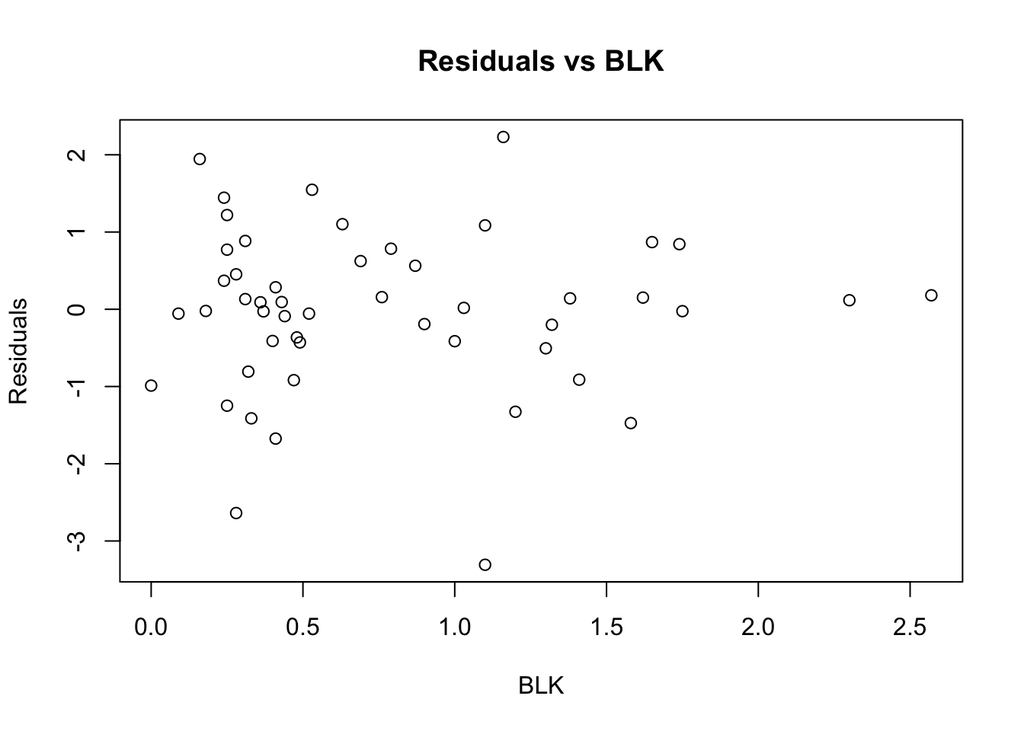

```r
plot(nbatable$BLK, rstudent(nbamodelred), main = "Residuals vs BLK", xlab = "BLK"
, ylab = "Residuals")
```

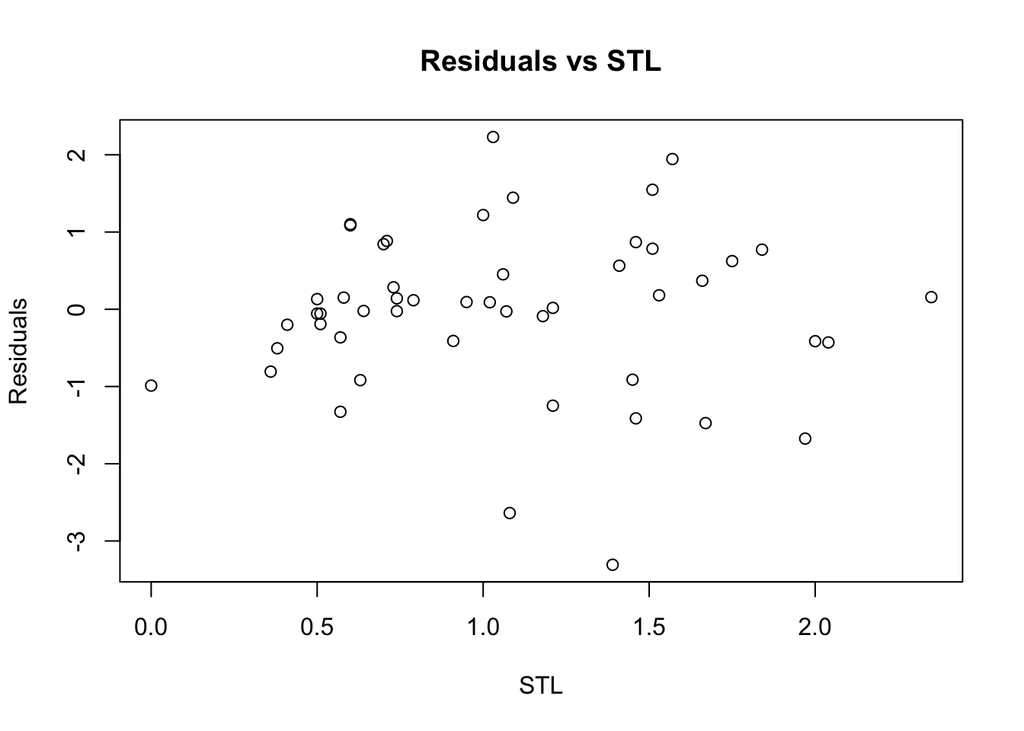

```r
plot(nbatable$STL, rstudent(nbamodelred), main = "Residuals vs STL", xlab = "STL"
, ylab = "Residuals")
```

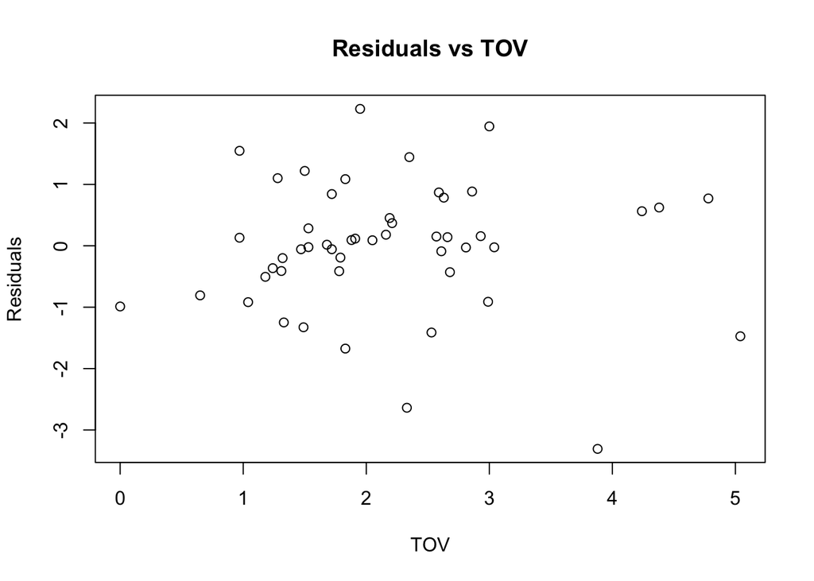

```r
plot(nbatable$TOV, rstudent(nbamodelred), main = "Residuals vs TOV", xlab = "TOV"
, ylab = "Residuals")
```

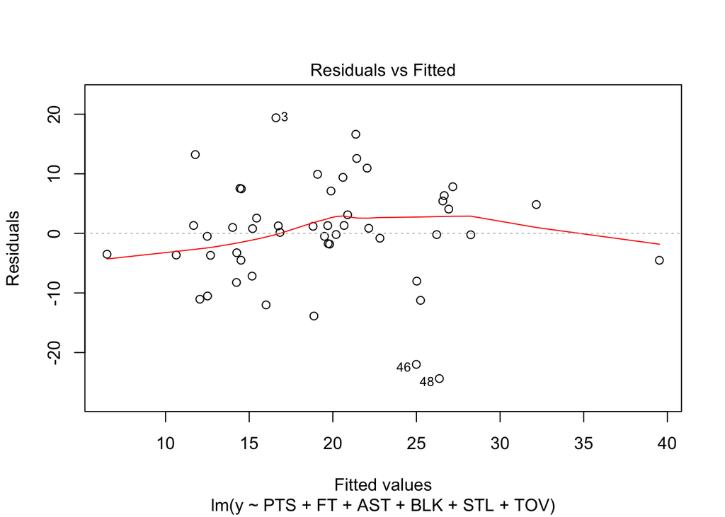

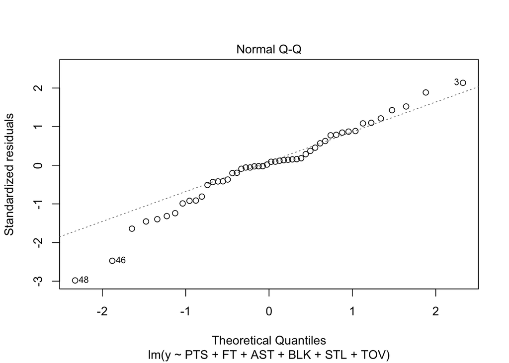

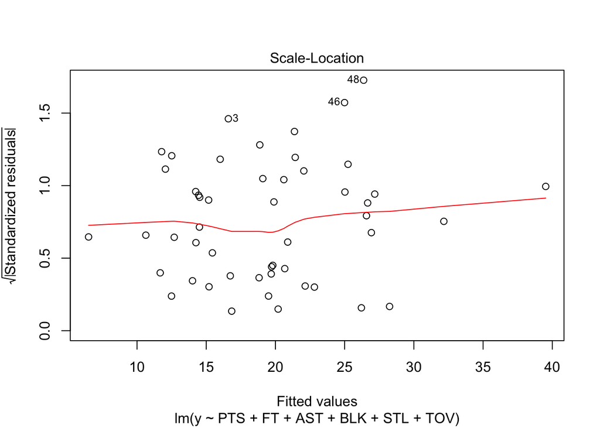

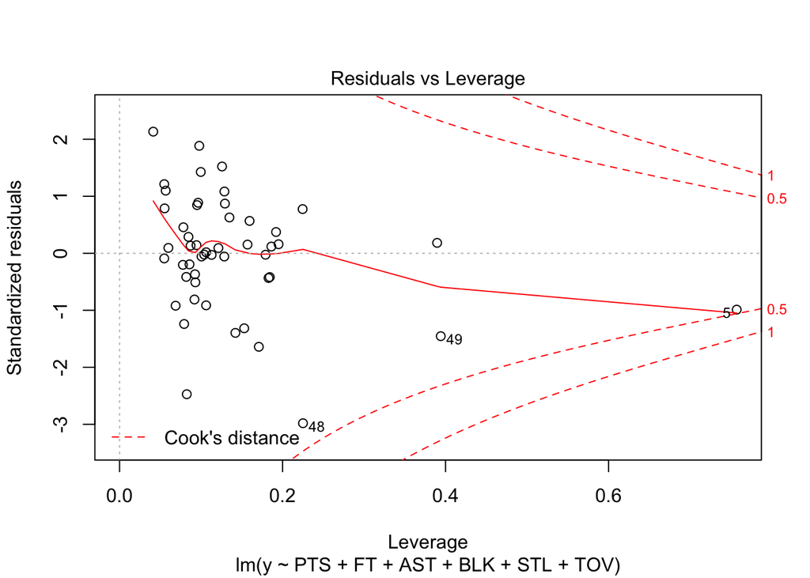

```r
plot(nbamodelred)
```

From the Normality Probability plot, we can assume the residuals are normally distributed.